# Dissolved oxygen data availability for the lower DRB

08 December 2021

## Records summary

### A Quick Look

Dissolved oxygen data was pulled from NWIS (for continuous and daily data) as well as the Water Quality Portal, which focuses on discrete (snapshot) samples. Specifically, for the WQP, we used the harmonized multiscale surface water quality dataset for the Delaware River Basin ([Shoda et al. 2019](https://doi.org/10.5066/P9PX8LZO)). We’re focused on dissolved oxygen reported in units of mg/L.

For NWIS, there were 38 continuous DO sites within the lower DRB. Some of those report the instantaneous values, but for older data only daily values were available. Here’s a breakdown of the sites/samples:

| data_src_simple | count_unique_sites | count_observation_days |
| --- | --- | --- |
| WQP | 1945 | 29382 |
| NWIS-daily | 26 | 96609 |
| NWIS-instantaneous | 12 | 9681 |

Combining the harmonized WQP dataset with data from NWIS (which includes data from NGWOS high-frequency stations), here is a map of site locations with dissolved oxygen data:

[interactive chart not shown]

For the WQP data, the number of DO records - as well as the number of different sites represented - picks up after ~2000.

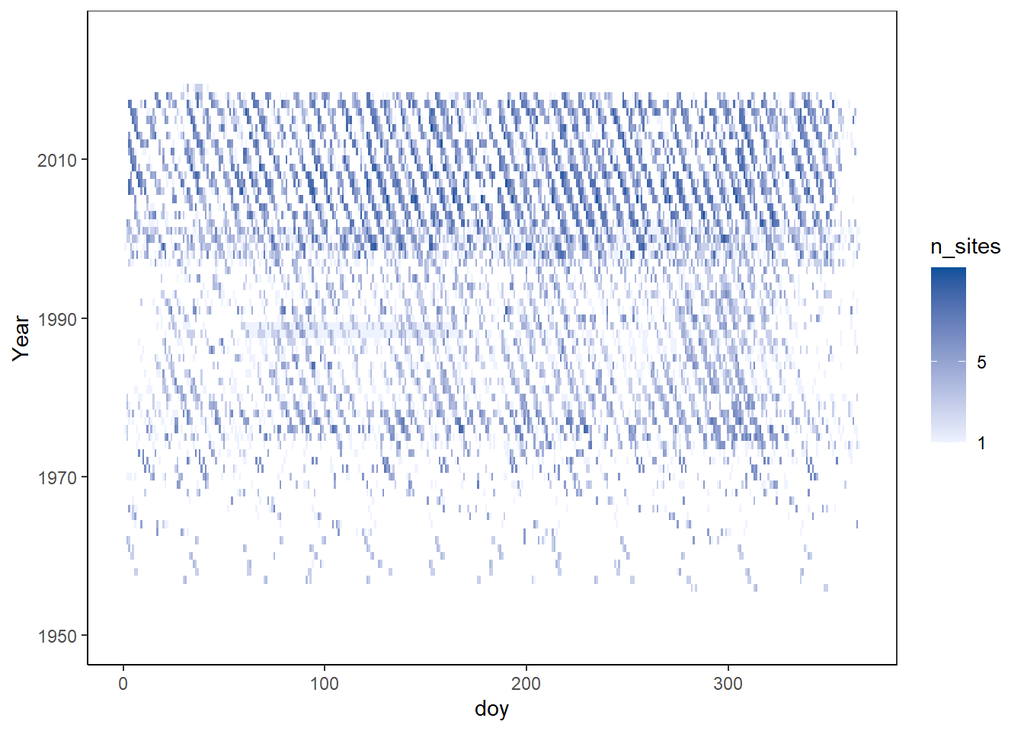

There is some seasonal bias to the NWIS continuous data, since some stations appear to pull their sensors over the winter:

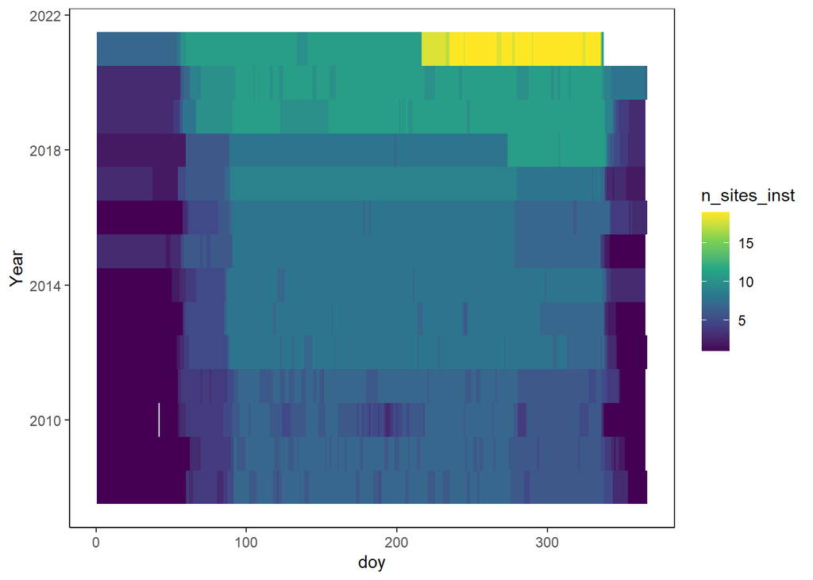